# AnDatosLabo1

```r
#source("/home/juan/Documentos/Rfunj/arranque_notebook.R")
```

```r
# Display Notebook
library("IRdisplay")

display_html('<style>.container { width:90% !important; }</style>') #ancho notebook
display_html('<style>.rendered_html {font-family: Ubuntu; font-size: 1.5em; }</style>') #fuente markdown renderizado
display_html('<style>.CodeMirror { width: 90%; font-family: Sans Serif ; font-size: 1.25em;}</style>') #fuente código
display_html('<style>.rendered_html table, .rendered_html th, .rendered_html tr, .rendered_html td {font-size: 100%;}</style>')
```

```r
# Borra consola, variables y funciones definidas en el entorno Global
cat("\014")
rm(list = setdiff(ls(), lsf.str()));
rm(list=lsf.str());

#carga librerías
library("lattice")
library("ggplot2")
library("latex2exp")
suppressMessages(library("crayon"))

#si no están instaladas, usar: install.packages("crayon", dependencies = T)
#obvio, cambiar crayon por las librerías que necesiten

#tamaño de la figura en Jupyter
fig <- function(width, heigth) {
    options(repr.plot.width = width, repr.plot.height = heigth)
}
```

```r
#tema de graficación
library("ggplot2")
temajuan <- theme(
  legend.position = c(0.14, 0.80),
  legend.background = element_blank(),
  legend.title = element_text(size = 28),
  legend.box = "horizontal",
  legend.direction = "vertical",
  plot.title = element_text(size = 28),
  #legend.key.height = unit(0.1,"snpc"),
  legend.key.width  = unit(0.075,"snpc"),
  #legend.box.spacing = unit(0.1,"snpc"),
  legend.key = element_blank(),
  legend.spacing.x = unit(3, "pt"),
  legend.text = element_text(size = 28, margin = margin(t = 0, r= 0, b = 0, l = 3, unit = "pt")),
  axis.line = element_line(size = 0.5, lineend = "square"),
  axis.title = element_text(size = 28),
  axis.text.x = element_text(size = 24, colour = "black", angle = 0,  vjust = 1),
  axis.text.y = element_text(size = 24, colour = "black"),
  axis.ticks = element_line(size = 1, colour = "black"),
  panel.border = element_rect(size = 1, fill = NA)
)
```

```r
dirGraficos <- "/home/juan/Documentos/Docencia/FEXPgit/FexpI/AnDatos/Labo1/graf"
dirDatos <- "/home/juan/Documentos/Docencia/fexpi/2024/DatosLabo1/"
```

# Análisis de datos del Labo 1

```r
setwd(dirDatos) #setea el directorio de trabajo
#los directorios de windows no se escriben igual.
getwd() #imprime el directorio de trabajo
list.files() #lista de archivos dentro del directorio de trabajo
```

'/home/juan/Documentos/Docencia/fexpi/2024/DatosLabo1'

1. 'AnDatosLabo1.ipynb'

2. 'g_Agustin.csv'

3. 'g_Alvaro.csv'

4. 'g_Brisa.csv'

5. 'g_Estefania .csv'

6. 'g_Fabri.csv'

7. 'g_Facundo.csv'

8. 'g_Fedra.csv'

9. 'g_Felipe.csv'

10. 'g_Franco.csv'

11. 'g_Marcelo.csv'

12. 'g_nahuel.csv'

13. 'g_NicoNavratil.csv'

14. 'graf'

15. 'g_Tijera.csv'

16. 'hist_g.pdf'

17. 'TodoElCurso1.pdf'

18. 'TodoElCursoViolin.pdf'

```r
#cargamos datos a variable tipo data.frame
datos <- read.csv("g_Franco.csv", skip = 1, header = F, sep = ",");
#imprime el dataframe
head(datos)
```

A data.frame: 6 × 5

|  | V1 <dbl> | V2 <dbl> | V3 <dbl> | V4 <dbl> | V5 <dbl> |
| --- | --- | --- | --- | --- | --- |
| 1 | 0.02132280 | -0.2985046 | -0.2811567 | 9.816854 | 9.825414 |
| 2 | 0.02382280 | -0.2985046 | -0.2811567 | 9.816854 | 9.825414 |
| 3 | 0.02632280 | -0.2985046 | -0.2811567 | 9.816854 | 9.825414 |
| 4 | 0.02883848 | -0.3272185 | -0.2572284 | 9.833604 | 9.842408 |
| 5 | 0.03136525 | -0.3152544 | -0.2596213 | 9.812068 | 9.820563 |
| 6 | 0.03385988 | -0.3176472 | -0.2524428 | 9.816854 | 9.825235 |

```r
#cambiamos los nombres de las columnas
#como el  teléfono estaba en reposo, le ponemos g
colnames(datos) <- c("t", "gx", "gy", "gz", "g");
head(datos) #imprimimos para corroborar
nrow(datos) #cantidad de filas del dataframe
```

A data.frame: 6 × 5

|  | t <dbl> | gx <dbl> | gy <dbl> | gz <dbl> | g <dbl> |
| --- | --- | --- | --- | --- | --- |
| 1 | 0.02132280 | -0.2985046 | -0.2811567 | 9.816854 | 9.825414 |
| 2 | 0.02382280 | -0.2985046 | -0.2811567 | 9.816854 | 9.825414 |
| 3 | 0.02632280 | -0.2985046 | -0.2811567 | 9.816854 | 9.825414 |
| 4 | 0.02883848 | -0.3272185 | -0.2572284 | 9.833604 | 9.842408 |
| 5 | 0.03136525 | -0.3152544 | -0.2596213 | 9.812068 | 9.820563 |
| 6 | 0.03385988 | -0.3176472 | -0.2524428 | 9.816854 | 9.825235 |

11940

***a. ¿Los valores son todos iguales? De haber diferencias, las atribuı́mos a variaciones en $|g|$ ó a inestabilidad del acelerómetro? Informe el mayor valor y el menor valor de la colección de medidas.***

```r
range(datos$g); #mínimo y máximo
#imprime
cat(bold$blue("g_min = ",min(datos$g), "m/s^2 \n"))
cat(bold$red("g_max = ",max(datos$g), "m/s^2 \n"))
```

1. 9.721172531

2. 9.935965159

```
g_min =  9.721172531 m/s^2
g_max =  9.935965159 m/s^2
```

***b. Consulte $|g|$ en la página de la Red Argentina de Gravedad Absoluta. Tome el valor medido en La Florida, $g_{RAGA}$ . A este valor lo consideraremos una referencia en la medida, es decir, lo consideraremos el valor verdadero.***

```r
#hacemos variables para los valores de g de la RAGA
g_RAGA <-  9.79316985
dg_RAGA <- 0.00000020
```

***c. Calculemos el valor absoluto de la diferencia |g acel − g RAGA| ¿elegimos el valor de g acel que esté más cercano y descartamos el resto? ¿a qué se debe que exista uno más cercano? ¿justo ese midió mejor o las medidas entregan valores al azar ?***

```r
# hacemos una nueva columna, a la que le asignamos el valor absoluto
# de la diferencia de cada valor de datos$g con g_RAGA
datos$dif_g <- abs(datos$g - g_RAGA)
```

```r
min(datos$dif_g) #mínimo de la diferencia anterior
min <- which(datos$dif_g == min(datos$dif_g)) #en qué fila está la menor diferencia...
```

1.49399999926914e-06

Para que las cantidades como la ***media muestral*** y la ***desviación estándar*** sean representativas de las incertezas, necesitamos que las medidas se muestren como una ***nube*** alrededor de la ***media***...

Es habitual corroborar esto mediante un gráfico, que en el eje vertical tiene la magnitud medida y en el eje horizontal simplemente el número de medida:

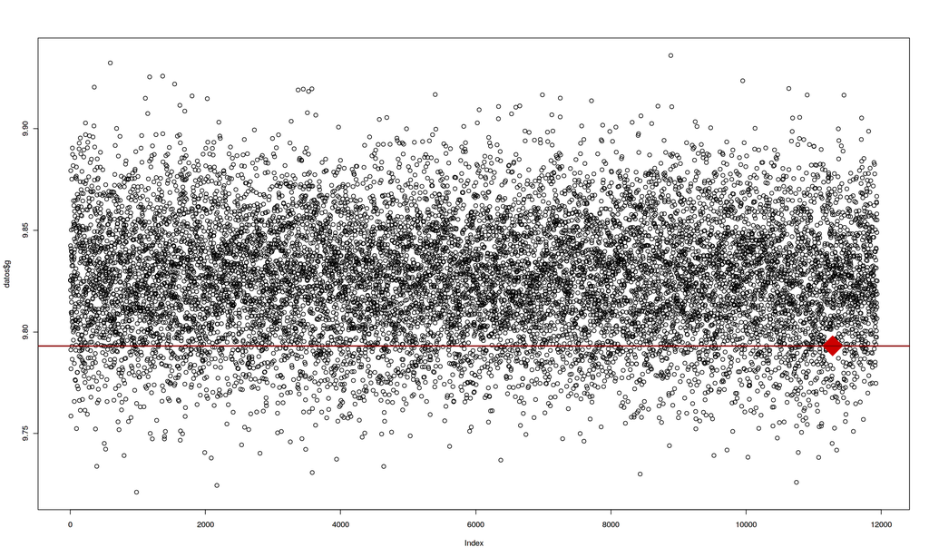

```r
fig(20,12)
# graficamos los valores de g
plot(datos$g)

#graficamos el punto de la menor diferencia con g_RAGA
points(min, datos$g[min], cex = 6, col = "red3", pch = 18)
#línea horizontal con el valor de g_RAGA
abline(b = 0, a = g_RAGA, col = "red4", lwd = 2)
```

***d. Una de las maneras de tratar con este tipo de datos, es hacer un promedio. Escriba la definición de promedio, calcule e informe. En términos más formales, al promedio le decimos media muestral, y en el caso en que sea una media muestral de una colección de valores $g_i$ , escribiremos la media muestral con una barra arriba, $\bar{g}$.***

Recordamos que la ***media muestral***, conocido habitualmente como* promedio* de un número de una colección de $n$ elementos, $g_1,g_2,g_3,...,g_n$, está dada por:

$$\bar{g} = \frac{g_1+g_2+g_3+...+g_n}{n} = \frac{1}{n}\sum_{i=1}^{n}g_i$$

hacerlo con calculadora para 20 valores puede ser incómodo. Para 4000 valores es un trabajo inadmisible.

```r
#g_acel es la media (mean, en inglés) de los datos g
g_acel <- mean(datos$g)
cat(bold$blue("g_media_muestral = ", g_acel, " m/s^2"))
```

```
g_media_muestral =  9.82628251858333  m/s^2
```

**e) Dibuje un histograma de las medidas. ¿Por qué la media muestral serı́a representativa?**

Abajo está el código para hacer un histograma, es de la librería ggplot2.

Tiene bastantes cosas, lo que es importante destacar es que cada línea define diferentes cosas, desde el histograma, pasando por las líneas verticales indicando $\bar{g}$ y $g_{RAGA}$ , además de títulos de gráficos, colores, etc.

Pueden probar cambiando algo, por gusto por ahora, luego veremos que los gráficos en ciencias tienen su *manera estándard* de armarse.

```r
glimpio <- datos$g

histo <- ggplot() + #crea objeto ggplot
  #dibuja histograma
  geom_histogram(aes(glimpio),bins = nclass.FD(glimpio), colour = "Black", alpha = 0.4, lwd = 0.2, show.legend = F) + #la capa del histograma
  # líneas horizontales
  geom_vline(aes(xintercept = g_acel, colour = "g acel" ), lwd = 2 ) +
  geom_vline(aes(xintercept = g_RAGA, colour = "g RAGA" ), lwd = 2 ) +
  # color para identificar líneas
  scale_colour_manual(values = c("g acel" = "Red3", "g RAGA" = "DeepSkyBlue4"),
                      labels = list(TeX("$\\; \\bar{g}_{acel}$"),TeX("$\\;\\;\\; \\bar{g}_{RAGA}$")),name = NULL) +

#títulos gráfico y ejes
  ylab("Frecuencia") + xlab(TeX("$g \\; (m \\, s^{-2} ) $")) +
  ggtitle("Medidas del Acelerómetro (Franco)") +
  scale_y_continuous(expand = expansion(mult = c(0,0.1)) ) +
  #detalles de la leyenda para leer el gráfico
    temajuan +
  theme(legend.position = c(0.15,0.8), legend.direction = "horizontal", legend.key.height = unit(48,"pt"),
        legend.key.width = unit(72,"pt"),  legend.text =  element_text(hjust = 12),
        legend.background = element_blank())


fig(width = 20,12)
```

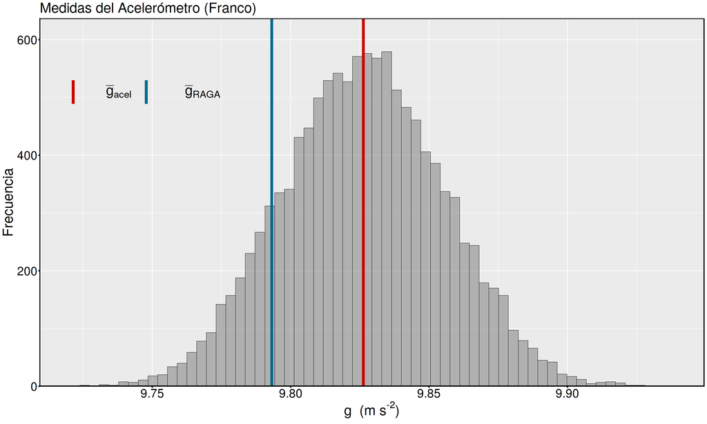

```r
show(histo)
```

```r
#guarda gráfico en pdf, en la carpeta de trabajo
setwd(dirGraficos)
ggsave(plot = histo, filename = "hist_g.pdf", device = "pdf", height = 6, width = 9) #buscar en la carpeta
```

***f ) Calcule la desviación estándar de la muestra, s. Defínala, calculela e informe el valor. ¿Por qué s (la desviación estándar de la muestra) sería una medida de dispersión de la medida?***

$$s_g =\frac{1}{\sqrt{n-1}}\sqrt{\Big((\,g_1 - \bar{g} \,)^2 + (\,g_2 - \bar{g} \,)^2 + ...+(\,g_n - \bar{g} \,)^2 \Big)} =\sum_{i = 1}^{n}\sqrt{\frac{(\,g_i - \bar{g} \,)^2}{n-1}}$$

La desviación estándar es una medida de cuán disperso está el conjunto de valores respecto de la media muestral de los datos. Para una distribución de valores $g_i$, los valores que se encuentren más lejos de $\bar{g}$ aportarán mucho al valor de $s_g$

```r
sg <- sd(datos$g) #la desviación estándar se calcula con la función sd(vector numérico)

cat(bold$blue("La desviación estándard g_Franco es \n\ns_g = ", sg, " m/s^2"))
```

```
La desviación estándard g_Franco es

s_g =  0.0291410387469385  m/s^2
```

la desviación estándar, además, tiene las unidades de la media muestral.

Es habitual resumir los resultados del histograma (bajo ciertas condiciones que veremos luego), expresando la media muestral +- la desviación estándar, es decir:

$$\boxed{\bar{g} \pm s_g = (9.8263 \;\pm \;0.0291) m s^{-2} \;}$$

## Con los datos de todo el curso

#### **g.** Informe la medida como la media muestral más menos una desviación estándar de la muestra $\bar{g} ± s_g$ .Subiendo los datos a la carpeta de Google Drive de los laboratorios (g_SuNombre.csv, por ejemplo `g_Juan.csv`), compare mediante una gráfica que en el eje vertical tenga los datos de g y en el eje horizontal tenga los nombres de cada estudiante. Dibuje una lı́nea horizontal que indique el valor de $g_{RAGA}$.

```r
#vemos los nombres de archivos
setwd(dirDatos)
archivos <- list.files(); #todos los archivos
archivos <- archivos[grep(archivos, pattern = ".csv")] #sólo los que sean de extensión .csv
archivos

indice <- vector(mode = "numeric");
t      <- vector(mode = "numeric");
g      <- vector(mode = "numeric");
Nombre <- vector(mode = "character");

for(i in archivos){
g_individual <- read.csv(i, header = F, skip = 1, sep = ","); #cargamos i = "g_Agustina.csv", "g_Antonella.csv"..."g_Tadeo.csv"

g_individual <- g_individual[, -(2:4)];

colnames(g_individual) <- c("t", "g");

nombre <- rep(gsub(x = i, c("g_|.csv"), replacement = ""), times = nrow(g_individual));

indice = c(indice,1:nrow(g_individual))
t <- c(t, g_individual$t)
g <- c(g, g_individual$g)
Nombre <- c(Nombre, nombre)



}

d_tutti <- data.frame(indice , t , g , Nombre)
head(d_tutti);
tail(d_tutti)
```

1. 'g_Agustin.csv'

2. 'g_Alvaro.csv'

3. 'g_Brisa.csv'

4. 'g_Estefania .csv'

5. 'g_Fabri.csv'

6. 'g_Facundo.csv'

7. 'g_Fedra.csv'

8. 'g_Felipe.csv'

9. 'g_Franco.csv'

10. 'g_Marcelo.csv'

11. 'g_nahuel.csv'

12. 'g_NicoNavratil.csv'

13. 'g_Tijera.csv'

A data.frame: 6 × 4

|  | indice <dbl> | t <dbl> | g <dbl> | Nombre <fct> |
| --- | --- | --- | --- | --- |
| 1 | 1 | 0.00952521 | 9.684970 | Agustin |
| 2 | 2 | 0.01150882 | 9.680173 | Agustin |
| 3 | 3 | 0.01352294 | 9.670537 | Agustin |
| 4 | 4 | 0.01550655 | 9.682675 | Agustin |
| 5 | 5 | 0.01752068 | 9.685068 | Agustin |
| 6 | 6 | 0.01950429 | 9.675447 | Agustin |

A data.frame: 6 × 4

|  | indice <dbl> | t <dbl> | g <dbl> | Nombre <fct> |
| --- | --- | --- | --- | --- |
| 340725 | 19483 | 99.99615 | 9.842390 | Tijera |
| 340726 | 19484 | 100.00128 | 9.842673 | Tijera |
| 340727 | 19485 | 100.00640 | 9.855026 | Tijera |
| 340728 | 19486 | 100.01153 | 9.858652 | Tijera |
| 340729 | 19487 | 100.01666 | 9.850183 | Tijera |
| 340730 | 19488 | 100.02178 | 9.861254 | Tijera |

```r
g_media <- vector(mode = "numeric");
sd_g <-  vector(mode = "numeric");
Nombre <- unique(d_tutti$Nombre, );


for(i in 1:length(Nombre)){
g_individual <- d_tutti[d_tutti$Nombre == Nombre[i], ];

g_media[i] <- mean(g_individual$g);
sd_g[i] <- sd(g_individual$g)
}

resumen <- data.frame(Nombre,g_media, sd_g)
head(resumen, 15)
```

A data.frame: 13 × 3

|  | Nombre <fct> | g_media <dbl> | sd_g <dbl> |
| --- | --- | --- | --- |
| 1 | Agustin | 9.694762 | 0.011601896 |
| 2 | Alvaro | 10.036859 | 0.024226432 |
| 3 | Brisa | 9.817637 | 0.029071709 |
| 4 | Estefania | 9.874428 | 0.005531296 |
| 5 | Fabri | 9.846266 | 0.045301074 |
| 6 | Facundo | 9.791655 | 0.028670469 |
| 7 | Fedra | 9.726185 | 0.009171011 |
| 8 | Felipe | 9.870568 | 0.034314190 |
| 9 | Franco | 9.826283 | 0.029141039 |
| 10 | Marcelo | 9.748734 | 0.008447928 |
| 11 | nahuel | 9.828689 | 0.146841915 |
| 12 | NicoNavratil | 9.805941 | 0.018237412 |
| 13 | Tijera | 9.854627 | 0.010213776 |

#### **h.** Compare las medidas de todo el curso en cuanto a exactitud y precisión. ¿cuál acelerómetro es el más preciso? ¿cuál acelerómetro es el más exacto? Justifique. Primero vemos la ***discrepancia*** (diferencia) con le valor verdadero de la RAGA: esto nos da información sobre la ***exactitud***.

```r
resumen$discrepancia <- resumen$g_media - g_RAGA
resumen[order(abs(resumen$discrepancia)), ]
```

A data.frame: 13 × 4

|  | Nombre <fct> | g_media <dbl> | sd_g <dbl> | discrepancia <dbl> |
| --- | --- | --- | --- | --- |
| 6 | Facundo | 9.791655 | 0.028670469 | -0.001514782 |
| 12 | NicoNavratil | 9.805941 | 0.018237412 | 0.012771365 |
| 3 | Brisa | 9.817637 | 0.029071709 | 0.024467598 |
| 9 | Franco | 9.826283 | 0.029141039 | 0.033112669 |
| 11 | nahuel | 9.828689 | 0.146841915 | 0.035519463 |
| 10 | Marcelo | 9.748734 | 0.008447928 | -0.044436169 |
| 5 | Fabri | 9.846266 | 0.045301074 | 0.053096459 |
| 13 | Tijera | 9.854627 | 0.010213776 | 0.061456814 |
| 7 | Fedra | 9.726185 | 0.009171011 | -0.066984519 |
| 8 | Felipe | 9.870568 | 0.034314190 | 0.077397721 |
| 4 | Estefania | 9.874428 | 0.005531296 | 0.081258054 |
| 1 | Agustin | 9.694762 | 0.011601896 | -0.098408129 |
| 2 | Alvaro | 10.036859 | 0.024226432 | 0.243689479 |

Vemos que Facundo tiene la media más cercana a $g_{RAGA}$, con lo cual es el valor más exacto.

La ***precisión*** la evaluamos mirando la desviación estándar. La precisión es cuán **juntos** están los valores entre sí, por lo que las medidas *menos precisas* tienden a tener más dispersión, es decir, mayor desviación estándar (es una relación inversa).

```r
resumen[order(resumen$sd_g), ]
```

A data.frame: 13 × 4

|  | Nombre <fct> | g_media <dbl> | sd_g <dbl> | discrepancia <dbl> |
| --- | --- | --- | --- | --- |
| 4 | Estefania | 9.874428 | 0.005531296 | 0.081258054 |
| 10 | Marcelo | 9.748734 | 0.008447928 | -0.044436169 |
| 7 | Fedra | 9.726185 | 0.009171011 | -0.066984519 |
| 13 | Tijera | 9.854627 | 0.010213776 | 0.061456814 |
| 1 | Agustin | 9.694762 | 0.011601896 | -0.098408129 |
| 12 | NicoNavratil | 9.805941 | 0.018237412 | 0.012771365 |
| 2 | Alvaro | 10.036859 | 0.024226432 | 0.243689479 |
| 6 | Facundo | 9.791655 | 0.028670469 | -0.001514782 |
| 3 | Brisa | 9.817637 | 0.029071709 | 0.024467598 |
| 9 | Franco | 9.826283 | 0.029141039 | 0.033112669 |
| 8 | Felipe | 9.870568 | 0.034314190 | 0.077397721 |
| 5 | Fabri | 9.846266 | 0.045301074 | 0.053096459 |
| 11 | nahuel | 9.828689 | 0.146841915 | 0.035519463 |

#### i. Haga la media de todos los datos del curso, y la desviación estándar de todos los datos. Compare con sus valores y con el valor de la RAGA.

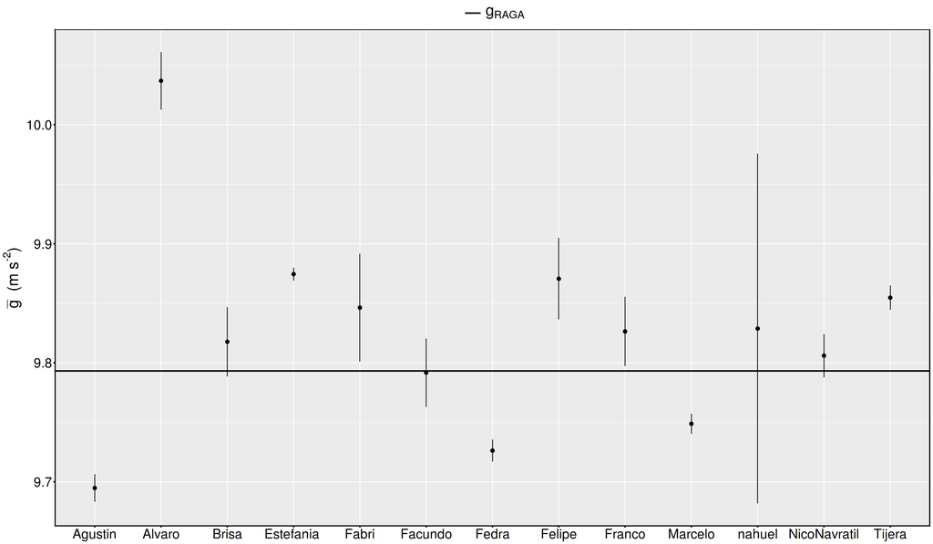

```r
gresumen <-  ggplot(data = resumen) +
geom_pointrange(aes(x = Nombre,y = g_media, ymin = g_media - sd_g, ymax = g_media + sd_g )) +
geom_hline(aes(yintercept = g_RAGA, lty = "g_RAGA"), lwd = 1) +
scale_linetype_manual(values = c("g_RAGA" = 1), labels = list(TeX("$g_{RAGA}$"))) +
ylab(TeX("$\\bar{g} \\; (m \\, s^{-2})$")) + xlab(NULL) +
temajuan +
theme(legend.direction = "horizontal",
      legend.position = "top",
      legend.title = element_blank())
fig(24,14)
show(gresumen)
```

- Exactitud:
  - Facundo ganador por lejos.
  - Álvaro último en la lista.
- Precisión:
  - Estefanía las medidas más cercanas entre sí.
  - Nahuel, algo habrá pasado.

```r
setwd(dirGraficos)
```

```r
ggsave(plot = gresumen, file = "TodoElCurso1.pdf" ,device = pdf, width = 24, height = 14 )
setwd(dirDatos)
```

**h.** Compare las medidas de todo el curso en cuanto a exactitud y precisión. ¿cuál acelerómetro es el más preciso? ¿cuál acelerómetro es el más exacto? Justifique.

# Un poco más allá.

Las barritas de incerteza indicando la desviación estándar, en este caso tienen sentido sólo si las medidas son ***estables***. Es por esto que necesitamos ver un gráfico de dispersión antes de hace un histograma, o tener los ojos muy afinados viendo todos los histogramas juntos.

De hecho, se puede hacer un gráfico de ***violín***, que son como histogramas espejados, y mirar qué pasa:

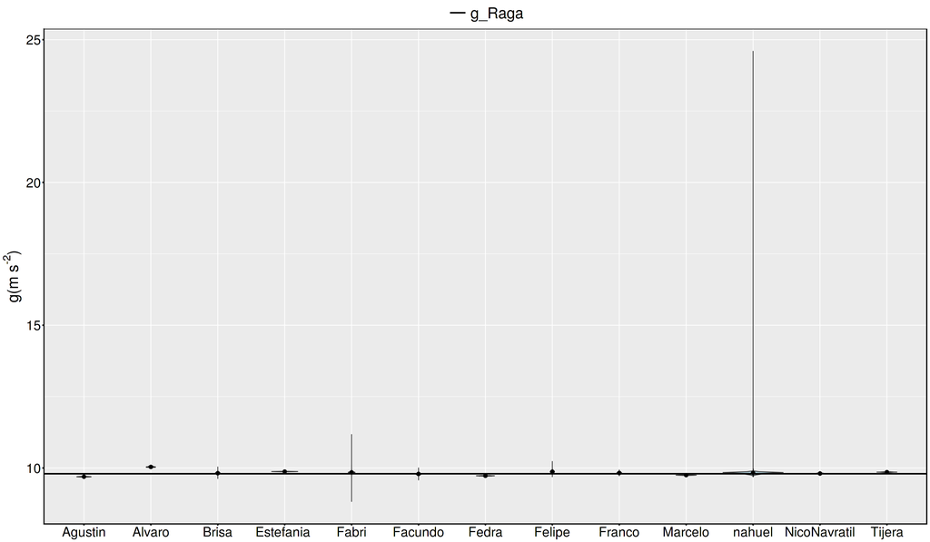

```r
gviolin <- ggplot() +
geom_violin(data = d_tutti,aes(x = Nombre,y = g), fill = "Deepskyblue4", alpha = 0.3) +
geom_pointrange(data = resumen, aes(x = Nombre,y = g_media, ymin = g_media - sd_g, ymax = g_media + sd_g )) +
geom_hline(aes(yintercept = g_RAGA, lty = "g_Raga"), lwd = 1) +
xlab(NULL) +
ylab(TeX("$g (m \\, s^{-2})$")) +
temajuan +
theme(legend.direction = "horizontal",
      legend.position = "top",
      legend.title = element_blank())

gviolin
```

Hay una medida de Nahuel que está arriba de $20 m s^{-2}$. Esto impide la búsqueda de detalles, porque nos hace el rango del eje vertical gigante. Esa medida es un ***valor anómalo*** y La vamos a sacar.

```r
dnuevo <- d_tutti[d_tutti$g < 20, ]
```

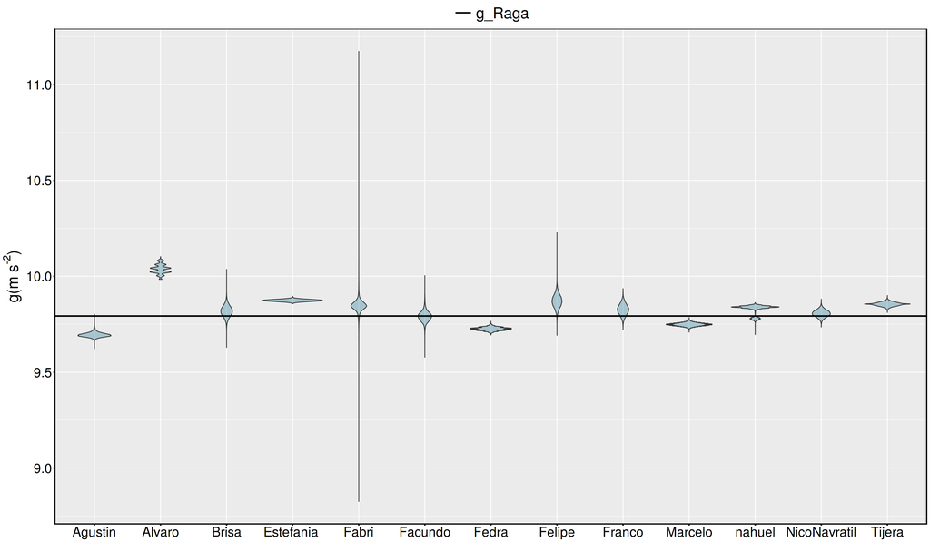

```r
gviolin <- ggplot() +
geom_violin(data = dnuevo,aes(x = Nombre,y = g), fill = "Deepskyblue4", alpha = 0.3) +
#geom_pointrange(data = resumen, aes(x = Nombre,y = g_media, ymin = g_media - sd_g, ymax = g_media + sd_g )) +
geom_hline(aes(yintercept = g_RAGA, lty = "g_Raga"), lwd = 1) +
ylab(TeX("$g (m \\, s^{-2})$")) + xlab(NULL) +
temajuan +
theme(legend.direction = "horizontal",
      legend.position = "top",
      legend.title = element_blank())

gviolin
```

Lo mismo pasa con Fabricio, cuya medida debe tener unos enormes picos causados por un sacudón del teléfono. Los sacamos:

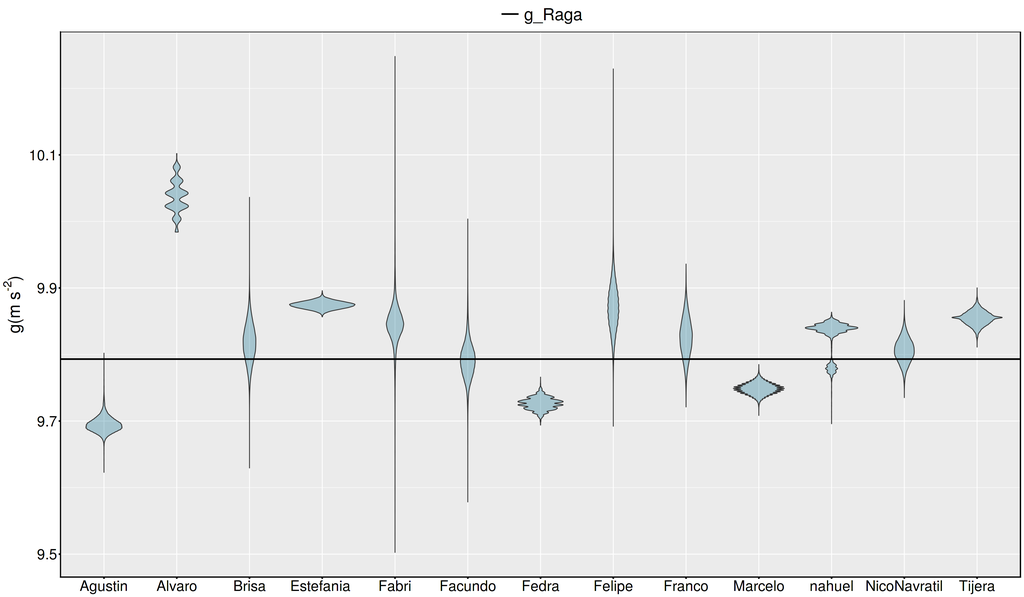

```r
dnuevo <- dnuevo[dnuevo$g < 10.25 & dnuevo$g > 9.5, ]
gviolin <- ggplot() +
geom_violin(data = dnuevo,aes(x = Nombre,y = g), fill = "Deepskyblue4", alpha = 0.3) +
#geom_pointrange(data = resumen, aes(x = Nombre,y = g_media, ymin = g_media - sd_g, ymax = g_media + sd_g )) +
geom_hline(aes(yintercept = g_RAGA, lty = "g_Raga"), lwd = 1) +
ylab(TeX("$g (m \\, s^{-2})$")) +
xlab(NULL) +
temajuan +
theme(legend.direction = "horizontal",
      legend.position = "top",
      legend.title = element_blank())

gviolin
setwd(dirGraficos)
ggsave(plot = gviolin, file = "TodoElCursoViolin.pdf" ,device = pdf, width = 24, height = 14 )
setwd(dirDatos)
```

De la gráfica anterior concluyo que:

1. Brisa, Fabricio, Facundo y Felipe tienen dispersiones grandes por la presencia de valores anómales, es decir, seguro que sacudieron el teléfono cuando midieron.
2. Nahuel tiene algo más raro: la medida tiene ***dos modas*** o dos máximos, una superior, cercana a 9.85 ms^-2 (con más medidas allí) y una inferior, cercana a 9.78 ms^-2.
3. Álvaro y Fedra tienen confirgurado el acelerómetro con ***poca resolución***, de ahí que se vean montañitas en las densidades.

```r
d1 <- d_tutti[d_tutti$Nombre == "Brisa"| d_tutti$Nombre == "Fabricio" | d_tutti$Nombre == "Facundo" | d_tutti$Nombre == "Felipe" | d_tutti$Nombre == "Franco"  , ]
```

```r
gscatter <- ggplot(data = d1) +
geom_point(aes(x = t,y = g)) +
facet_grid(Nombre ~.) +
geom_hline(aes(yintercept = g_RAGA, lty = "g_Raga"), lwd = 1) +
xlab("t (s)") +
ylab(TeX("$g \\; (m \\, s^{-2})$")) +
temajuan +
theme(strip.text = element_text(size = 28),
    legend.direction = "horizontal",
      legend.position = "top",
      legend.title = element_blank()) +
guides(colour = guide_legend(override.aes = list(size = 4, alpha =1)))
```

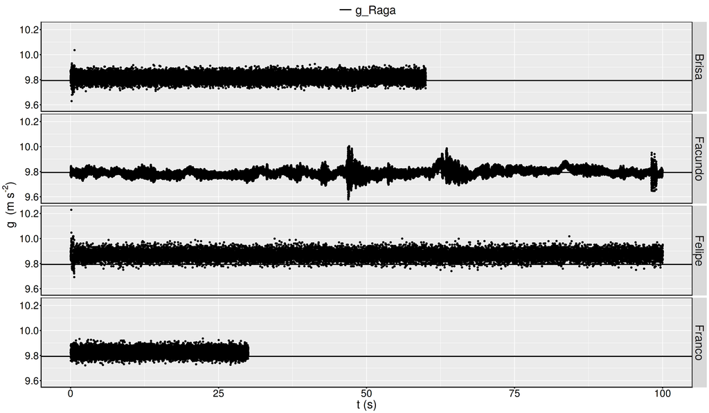

```r
show(gscatter)
```

## 2. Nahuel, con su medida de gravedad cuantizada (*primus inter pares*)

```r
setwd(dirDatos)
dnahuel <- d_tutti[d_tutti$Nombre == "nahuel", ];
dnahuel <- dnahuel[dnahuel$g < 20, ]
```

```r
dnahuel <- read.csv("g_nahuel.csv", skip = 1, header = F, sep = ",");
colnames(dnahuel) <- c("t", "gx", "gy", "gz", "g")
head(dnahuel)
dnahuel <- dnahuel[dnahuel$g < 20, ]
```

A data.frame: 6 × 5

|  | t <dbl> | gx <dbl> | gy <dbl> | gz <dbl> | g <dbl> |
| --- | --- | --- | --- | --- | --- |
| 1 | 0.01323965 | -0.42900 | -0.87300 | 24.576000 | 24.595243 |
| 2 | 0.01804396 | -0.20400 | -0.26895 | 9.760051 | 9.765887 |
| 3 | 0.02284826 | -0.20400 | -0.26700 | 9.754951 | 9.760736 |
| 4 | 0.02765257 | -0.19905 | -0.26895 | 9.760051 | 9.765784 |
| 5 | 0.03245665 | -0.20400 | -0.26700 | 9.754951 | 9.760736 |
| 6 | 0.03726095 | -0.20205 | -0.26700 | 9.760051 | 9.765793 |

```r
gnahuel <- ggplot(data = dnahuel) +
#geom_point(aes(x = t,y = gx), colour = "Red") +
#geom_point(aes(x = t,y = gy), colour = "Blue") +
geom_point(aes(x = t,y = gz), colour = "Green3") +
geom_point(aes(x = t,y = g), colour = "Black") +
geom_hline(aes(yintercept = g_RAGA, lty = "g_Raga"), lwd = 1) +
xlab("t (s)") +
ylab(TeX("$g \\; (m \\, s^{-2})$")) +
temajuan +
theme( legend.direction = "horizontal",
      legend.position = "top",
      legend.title = element_blank()) +
guides(colour = guide_legend(override.aes = list(size = 4, alpha =1)))
```

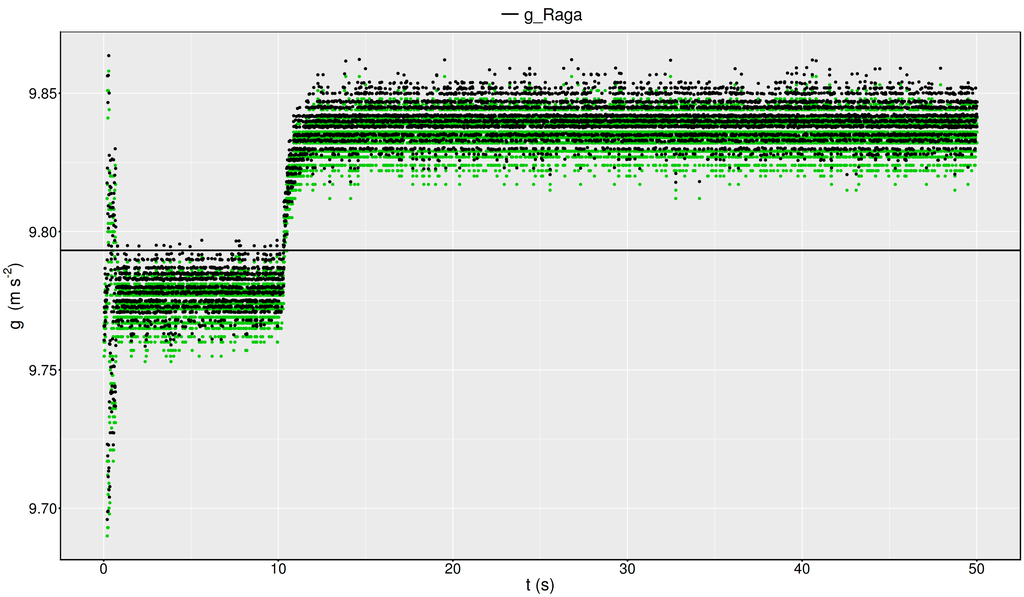

```r
show(gnahuel)
```

Nahuel sacudió el tel al principio y lo aceleró hasta dejarlo encima de la mesa...luego lo dejó quieto. Acá se puede descartar la primera parte de los datos.

En negro se muestra el módulo de la aceleración y en verde la aceleración en el eje z. Que varíen de la misma manera quiere decir que casi toda la variación en el módulo es explicada por la variación en el eje z.

Si vemos los ejes x e y:

```r
gnahuelxy <- ggplot(data = dnahuel) +
geom_point(aes(x = t,y = gx), colour = "Red") +
geom_point(aes(x = t,y = gy), colour = "Blue") +
xlab("t (s)") +
ylab(TeX("$g \\; (m \\, s^{-2})$")) +
temajuan +
theme( legend.direction = "horizontal",
      legend.position = "top",
      legend.title = element_blank()) +
guides(colour = guide_legend(override.aes = list(size = 4, alpha =1)))
```

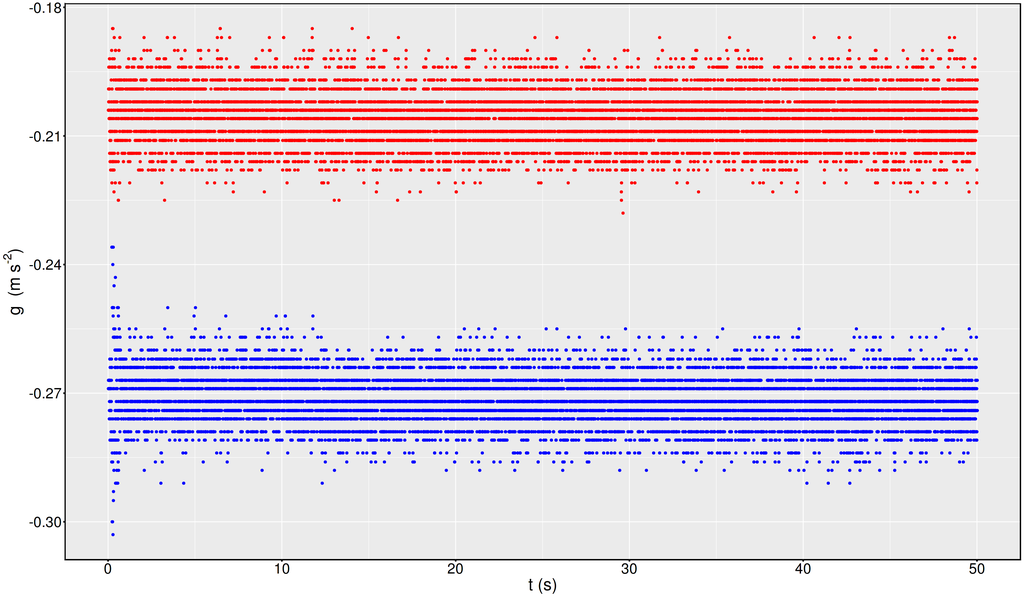

```r
show(gnahuelxy)
```

Las medidas de los ejes x e y permanecen casi constantes en valores bajos.

## 3. Álvaro y Fedra.

La resolución de un acelerómetro es la *mínima escala*, y tiene que ver con cuestiones de configuración (casi todos los acelerómetros de teléfonos pueden lograr a misma resolución con una configuración adecuada).

```r
daf <- d_tutti[d_tutti$Nombre == "Alvaro" | d_tutti$Nombre == "Fedra" |  d_tutti$Nombre == "Marcelo" | d_tutti$Nombre == "NicoNavratil",  ]
```

```r
gaf <- ggplot(data = daf) + geom_point(aes(x = t, y =g),alpha = 0.3) +
facet_grid(Nombre ~., scales = "free_y") +
ylab(TeX("$g (m \\, s^{-2})$")) +
 temajuan + theme(strip.text = element_text(size = 28))
```

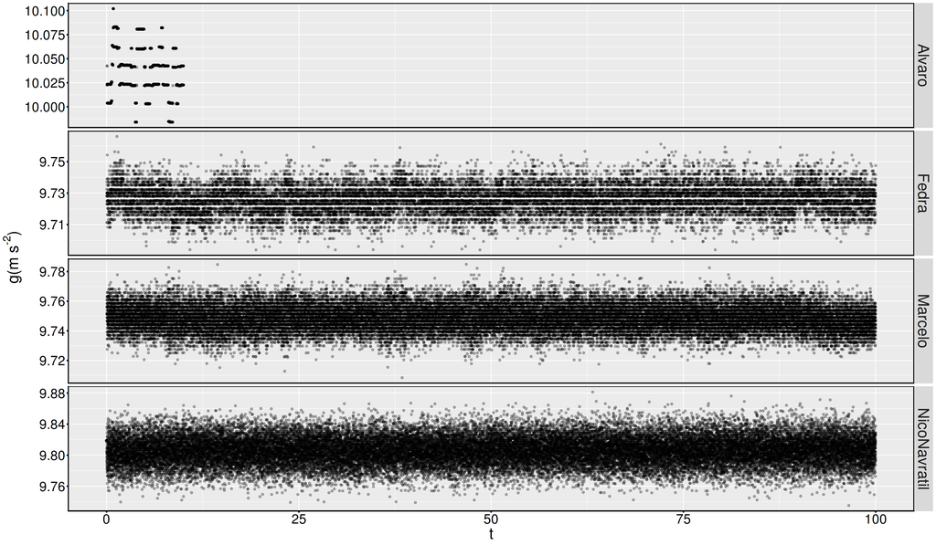

```r
show(gaf)
```

de mayor a menor discretización, las medidas de Álvaro son *muy discretas*, aunque esto no represente problemas, es sólo informativo.